# Final project

12/07/2019

# Set Up

## load packages

```r
library(ggplot2)
library(tidyverse)
library(dplyr)
library(lubridate)
library(party)
getwd()
```

```
[1] "/home/cuw91/STAT184 project/STAT184-projct-Chuzhen-Wang"
```

# Data Access

```r
#import and inspect dataset
googleplaystore <- read.csv("googleplaystore.csv")
str(googleplaystore)
```

```
'data.frame':   10841 obs. of  13 variables:
 $ App           : Factor w/ 9660 levels "- Free Comics - Comic Apps",..: 7206 2551 8970 8089 7272 7103 8149 5568 4926 5806 ...
 $ Category      : Factor w/ 34 levels "1.9","ART_AND_DESIGN",..: 2 2 2 2 2 2 2 2 2 2 ...
 $ Rating        : num  4.1 3.9 4.7 4.5 4.3 4.4 3.8 4.1 4.4 4.7 ...
 $ Reviews       : Factor w/ 6002 levels "0","1","10","100",..: 1183 5924 5681 1947 5924 1310 1464 3385 816 485 ...
 $ Size          : Factor w/ 462 levels "1,000+","1.0M",..: 55 30 368 102 64 222 55 118 146 120 ...
 $ Installs      : Factor w/ 22 levels "0","0+","1,000,000,000+",..: 8 20 13 16 11 17 17 4 4 8 ...
 $ Type          : Factor w/ 4 levels "0","Free","NaN",..: 2 2 2 2 2 2 2 2 2 2 ...
 $ Price         : Factor w/ 93 levels "$0.99","$1.00",..: 92 92 92 92 92 92 92 92 92 92 ...
 $ Content.Rating: Factor w/ 7 levels "","Adults only 18+",..: 3 3 3 6 3 3 3 3 3 3 ...
 $ Genres        : Factor w/ 120 levels "Action","Action;Action & Adventure",..: 10 13 10 10 12 10 10 10 10 12 ...
 $ Last.Updated  : Factor w/ 1378 levels "1.0.19","April 1, 2016",..: 562 482 117 825 757 901 76 726 1317 670 ...
 $ Current.Ver   : Factor w/ 2834 levels "","0.0.0.2","0.0.1",..: 122 1020 468 2827 280 116 280 2393 1457 1431 ...
 $ Android.Ver   : Factor w/ 35 levels "","1.0 and up",..: 17 17 17 20 22 10 17 20 12 17 ...
```

```r
googleplayreview <- read.csv("googleplaystore_user_reviews.csv")
str(googleplayreview)
```

```
'data.frame':   64295 obs. of  5 variables:
 $ App                   : Factor w/ 1074 levels "10 Best Foods for You",..: 1 1 1 1 1 1 1 1 1 1 ...
 $ Translated_Review     : Factor w/ 27996 levels "","___ ___ ___ ___ ___ 0",..: 9279 23853 17229 27355 2076 2168 1032 17229 15968 13280 ...
 $ Sentiment             : Factor w/ 4 levels "nan","Negative",..: 4 4 1 4 4 4 4 1 3 3 ...
 $ Sentiment_Polarity    : num  1 0.25 NaN 0.4 1 1 0.6 NaN 0 0 ...
 $ Sentiment_Subjectivity: num  0.533 0.288 NaN 0.875 0.3 ...
```

# Data Analysis

### Research Question 1

#### Question a).What is the correlation between sentiment polarity and sentiment subjectivity of app reviews?

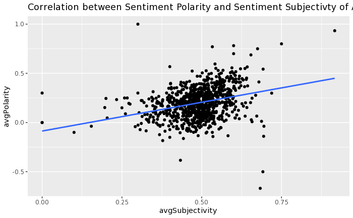

```r
#Calculate the average sentiment polarity and sentiment subjectivity for each app in the googleplayreview dataset
googleplayreviews <-
  googleplayreview %>%
  filter(Sentiment != "nan") %>%
  group_by(App) %>%
  summarise(total=n(),
            avgPolarity= mean(Sentiment_Polarity),
            avgSubjectivity = mean(Sentiment_Subjectivity))
#plot the relationship between sentiment polarity and sentiment subjectivity
regressionplot <-
  googleplayreviews%>%
  ggplot(aes(y = avgPolarity, x = avgSubjectivity))+
  geom_point()+
  geom_smooth(method="lm", se = FALSE)
print(regressionplot + ggtitle("Correlation between Sentiment Polarity and Sentiment Subjectivty of App reviews "))
```

#### Question b).What app has both high values of sentiment polarity and subjectivity, which are greater than 0.7?

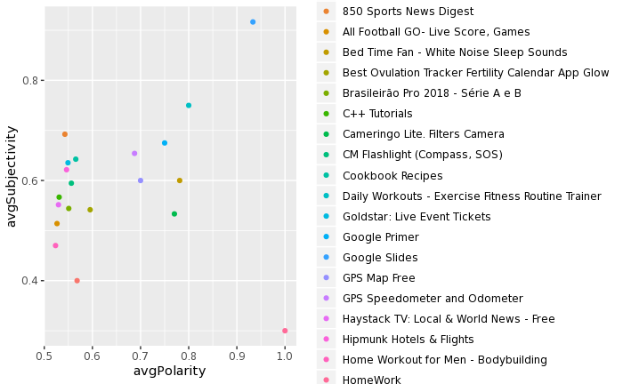

```r
#get the top 20 apps which has high sentiment Polarity
a <-
  googleplayreviews %>%
  arrange(desc(avgPolarity)) %>%
  head(20)
#Draw the scatter plot to see the app whose sentiment sujectivity and polarity are both greater than 0,.7
a %>%
  ggplot(aes(x=avgPolarity, y=avgSubjectivity)) +
  geom_point(aes(color=App))
```

Answer: Daily Workouts - Exercise Fitness Routine Trainer and Google Slides have both high values of sentiment polarity and subjectivity which are greater than 0.7.

### Research Question 2

#### Question: What’s the relationship between Rating, sentiment Subjectivity, sentiment Polarity?

```r
#Join two dataset by "App"
TopRating <-
  googleplaystore %>%
  inner_join(googleplayreviews) %>%
  select( App = App, Rating, avgPolarity,avgSubjectivity,Category ) %>%
  group_by(App,avgPolarity,Rating,avgSubjectivity,Category) %>%
  summarise(total=n(),
            avgRating= mean(Rating))
```

```
Column `App` joining factors with different levels, coercing to character vector
```

```r
TopRating
```

| App | avgPolarity | Rating | avgSubjectivity | Category | total | avgRating |
| --- | --- | --- | --- | --- | --- | --- |
| 10 Best Foods for You | 0.4707328207 | 4.0 | 0.4954547 | HEALTH_AND_FITNESS | 2 | 4.0 |
| 11st | 0.1812942145 | 3.8 | 0.4439569 | SHOPPING | 1 | 3.8 |
| 1800 Contacts - Lens Store | 0.3181447736 | 4.7 | 0.5910985 | MEDICAL | 2 | 4.7 |
| 1LINE – One Line with One Touch | 0.1962902996 | 4.6 | 0.5573153 | GAME | 1 | 4.6 |
| 2018Emoji Keyboard \U0001f602 Emoticons Lite -sticker&gif | 0.4495659722 | 4.2 | 0.5205729 | PERSONALIZATION | 1 | 4.2 |
| 21-Day Meditation Experience | 0.2580136785 | 4.4 | 0.5510480 | HEALTH_AND_FITNESS | 2 | 4.4 |
| 2Date Dating App, Love and matching | 0.2802671703 | 4.4 | 0.5583907 | DATING | 1 | 4.4 |
| 2GIS: directory & navigator | 0.2231290427 | 4.5 | 0.3966579 | TRAVEL_AND_LOCAL | 1 | 4.5 |
| 2ndLine - Second Phone Number | 0.1689682089 | 4.2 | 0.3770225 | COMMUNICATION | 1 | 4.2 |
| 2RedBeans | 0.4121991790 | 4.0 | 0.5978684 | DATING | 1 | 4.0 |

[output cut: 842 more lines]

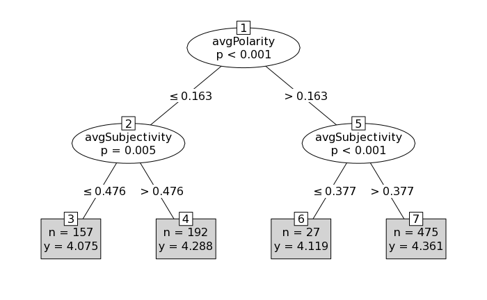

```r
d<-
  TopRating %>%
  select(Rating,avgSubjectivity,avgPolarity)%>%
  na.omit()
#model the sentiment subjectvity and sentiment polarity as the factors for Rating
mod1<- party::ctree(
    Rating ~ avgSubjectivity+avgPolarity,
    data=d)
plot(mod1,type="simple")
```

Answer: From the decision tree plot, we can see that sentiment Subjectivity and sentiment Polarity influence on the value of Rating.

### Research Question 3

#### Question: What apps contained in the googleplaystore_user_reviews dataset have high average rating which is greater than 4.6? Find the pattern of high rating apps.

```r
# unique App in googleplaystore dataset
googleplaystore %>%
  summarise(n_distinct(App))
```

| n_distinct(App) |
| --- |
| 9660 |

```r
# unique App in googlestore_user_reviews dataset after NA value deleted
googleplayreviews %>%
  summarise(n_distinct(App))
```

| n_distinct(App) |
| --- |
| 865 |

```r
#Join the tables of googleplaystore and googleplayreviews. Get the app whose average rating is not less than 4.8
TopRating2 <-
  TopRating %>%
  filter(avgRating >= 4.7)
TopRating2
```

| App | avgPolarity | Rating | avgSubjectivity | Category | total | avgRating |
| --- | --- | --- | --- | --- | --- | --- |
| 1800 Contacts - Lens Store | 0.31814477 | 4.7 | 0.5910985 | MEDICAL | 2 | 4.7 |
| 30 Day Fitness Challenge - Workout at Home | 0.33353687 | 4.8 | 0.5585879 | HEALTH_AND_FITNESS | 1 | 4.8 |
| Abs Training-Burn belly fat | 0.21741882 | 4.7 | 0.4469091 | HEALTH_AND_FITNESS | 1 | 4.7 |
| Ada - Your Health Guide | 0.30325629 | 4.7 | 0.5554172 | MEDICAL | 2 | 4.7 |
| All-In-One Toolbox: Cleaner, Booster, App Manager | 0.26733509 | 4.7 | 0.5456981 | PRODUCTIVITY | 1 | 4.7 |
| Amino: Communities and Chats | 0.04758960 | 4.8 | 0.5375361 | SOCIAL | 2 | 4.8 |
| ASOS | 0.31691664 | 4.7 | 0.5864045 | SHOPPING | 2 | 4.7 |
| Associated Credit Union Mobile | 0.38809283 | 4.7 | 0.5595349 | FINANCE | 1 | 4.7 |
| Backgrounds (HD Wallpapers) | 0.26443176 | 4.7 | 0.5990708 | PERSONALIZATION | 1 | 4.7 |
| Baritastic - Bariatric Tracker | 0.41827674 | 4.7 | 0.5710315 | MEDICAL | 1 | 4.7 |

[output cut: 55 more lines]

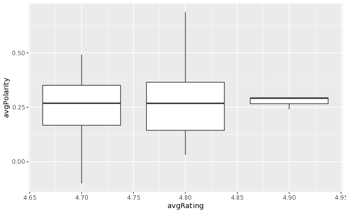

```r
#Inspect the average sentiment polartiy of high rating app
TopRating2 %>%
  group_by(avgRating,avgPolarity) %>%
  summarise(count =n()) %>%
  ggplot(aes(x=avgRating,y=avgPolarity, group=avgRating))+
  geom_boxplot()
```

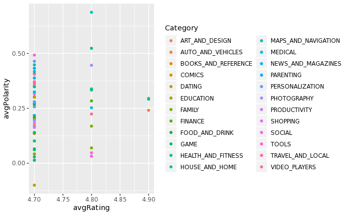

```r
TopRating2 %>%
  ggplot(aes(x=avgRating,y=avgPolarity,color = Category))+
  geom_point()
```

Answer: The TopRating table includes 64 Apps have greater than 4.6 average rating.From boxplot, we can see apps who have 4.8 average rating have highest variability of sentiment polarity since the range of middle boxplot is largest one.From the scatterplot, we can see the high rating apps mostly fall into 4.7 rating.

### Research Question 4

#### How many apps are there which have common use words you’re interested in? Examine them visually to find new app common name to add to the pattern, e.g. Free.

```r
#get the unique app names in googleplaystore dataset
Distinctapp <-
  googleplaystore %>%
  group_by(App)%>%
  summarise(total=n())
Distinctapp
```

| App | total |
| --- | --- |
| - Free Comics - Comic Apps | 1 |
| ¡Ay Caramba! | 1 |
| ¡Ay Metro! | 1 |
| ¿Es Vegan? | 1 |
| .R | 1 |
| "i DT" Fútbol. Todos Somos Técnicos. | 1 |
| [adult swim] | 1 |
| [BN] Blitz | 1 |
| [EF]ShoutBox | 1 |
| [root] Pry-Fi | 1 |

[output cut: 990 more lines]

```r
#App names which have below expression I want to extratct
pattern <- "(Art|Health|Google|Police|English|Beauty|Chat|Photo|Scan|Music|Free|Book|Mobile|Call|Learn|Home)"
#Set of matches extracted
AppNames <-
  Distinctapp %>%
  filter(grepl(pattern, App)) %>%
  tidyr::extract(App, into = "name", regex = pattern)
#frequency table
AppNameFrequency <-
  AppNames %>%
  group_by(name) %>%
  summarise(count =n()) %>%
  mutate(name = reorder(name,desc(count))) %>%
  arrange(desc(count))
AppNameFrequency
```

| name | count |
| --- | --- |
| Free | 318 |
| Mobile | 211 |
| Photo | 125 |
| Chat | 90 |
| Learn | 90 |
| Book | 64 |
| Call | 58 |
| Home | 56 |
| English | 49 |
| Google | 46 |

[output cut: 6 more lines]

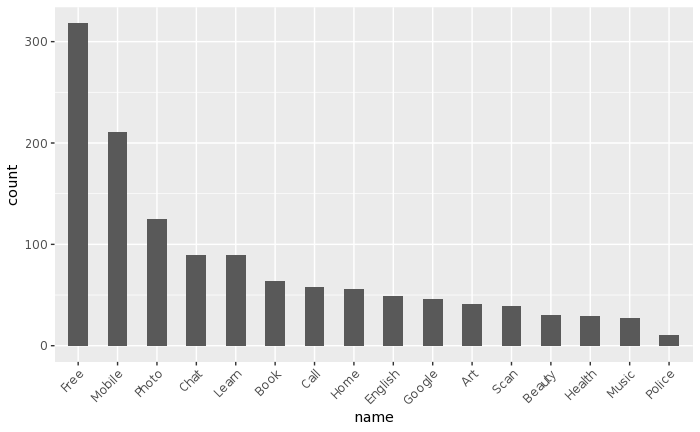

```r
#bar chart of frequency
AppNameFrequency %>%
  ggplot(aes(x= name,y=count)) +
  geom_bar(stat='identity',width=0.5) +
  theme(axis.text.x = element_text(angle = 45, hjust = 1 ))
```

ANswer: From the histogram of 16 patterns I identify, the App names including “Free” are the most .